# Homework dv05

Author

Jiantong Zhang

```r
library(tidyverse)
wncaa <- read_csv("https://raw.githubusercontent.com/vaiseys/dav-course/main/Data/wncaa.csv")
glimpse(wncaa)
```

```
Rows: 2,092
Columns: 19
$ year              <dbl> 1982, 1982, 1982, 1982, 1982, 1982, 1982, 1982, 1982…
$ school            <chr> "Arizona St.", "Auburn", "Cheyney", "Clemson", "Drak…
$ seed              <dbl> 4, 7, 2, 5, 4, 6, 5, 8, 7, 7, 4, 8, 2, 1, 1, 2, 3, 6…
$ conference        <chr> "Western Collegiate", "Southeastern", "Independent",…
$ conf_w            <dbl> NA, NA, NA, 6, NA, NA, NA, NA, NA, NA, NA, NA, NA, N…
$ conf_l            <dbl> NA, NA, NA, 3, NA, NA, NA, NA, NA, NA, NA, NA, NA, N…
$ conf_percent      <dbl> NA, NA, NA, 66.7, NA, NA, NA, NA, NA, NA, NA, NA, NA…
$ conf_place        <chr> "-", "-", "-", "4th", "-", "-", "-", "-", "-", "-", …
$ reg_w             <dbl> 23, 24, 24, 20, 26, 19, 21, 14, 21, 28, 24, 17, 22, …
$ reg_l             <dbl> 6, 4, 2, 11, 6, 7, 8, 10, 8, 7, 5, 13, 7, 5, 1, 6, 4…
$ reg_percent       <dbl> 79.3, 85.7, 92.3, 64.5, 81.3, 73.1, 72.4, 58.3, 72.4…
$ how_qual          <chr> "at-large", "at-large", "at-large", "at-large", "aut…
$ x1st_game_at_home <chr> "Y", "N", "Y", "N", "Y", "N", "N", "N", "N", "N", "Y…
$ tourney_w         <dbl> 1, 0, 4, 0, 2, 0, 0, 0, 0, 0, 2, 0, 2, 1, 5, 3, 1, 1…
$ tourney_l         <dbl> 1, 1, 1, 1, 1, 1, 1, 1, 1, 1, 1, 1, 1, 1, 0, 1, 1, 1…
$ tourney_finish    <chr> "RSF", "1st", "N2nd", "1st", "RF", "1st", "1st", "1s…
$ full_w            <dbl> 24, 24, 28, 20, 28, 19, 21, 14, 21, 28, 26, 17, 24, …
$ full_l            <dbl> 7, 5, 3, 12, 7, 8, 9, 11, 9, 8, 6, 14, 8, 6, 1, 7, 5…
$ full_percent      <dbl> 77.4, 82.8, 90.3, 62.5, 80.0, 70.4, 70.0, 56.0, 70.0…
```

## Question 1

```r
wncaa_new <- wncaa |>
  filter(tourney_finish == "Champ") |>
  group_by(school) |>
  summarize(N = n()) |>
  mutate(freq = N / sum(N))

wncaa_new
```

```
# A tibble: 15 × 3
   school                  N   freq
   <chr>               <int>  <dbl>
 1 Baylor                  2 0.0541
 2 Louisiana Tech          2 0.0541
 3 Maryland                1 0.0270
 4 North Carolina          1 0.0270
 5 Notre Dame              2 0.0541
 6 Old Dominion            1 0.0270
 7 Purdue                  1 0.0270
 8 South Carolina          1 0.0270
 9 Southern California     2 0.0541
10 Stanford                2 0.0541
11 Tennessee               8 0.216
12 Texas                   1 0.0270
13 Texas A&M               1 0.0270
14 Texas Tech              1 0.0270
15 UConn                  11 0.297
```

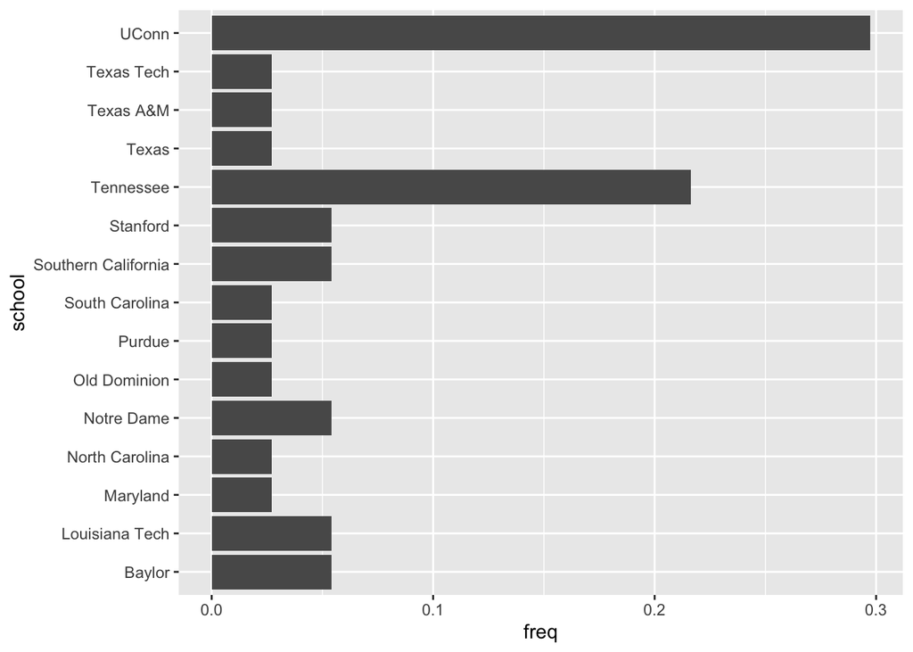

```r
ggplot(data=wncaa_new,
       mapping = aes(x= school, y= freq)) +
  geom_bar(stat= 'identity') +
  coord_flip()
```

Most schools won around 2.5-5% of tournaments. Uconn and Tennessee won the most tournaments, with Uconn winning nearly 30% and Tennessee winning over 20%.

## Question 2

```r
champs <- wncaa |>
  filter(tourney_finish == "Champ")
champ_names <- unique(champs$school)
```

```r
winners <- wncaa |>
  filter(school %in% champ_names)
```

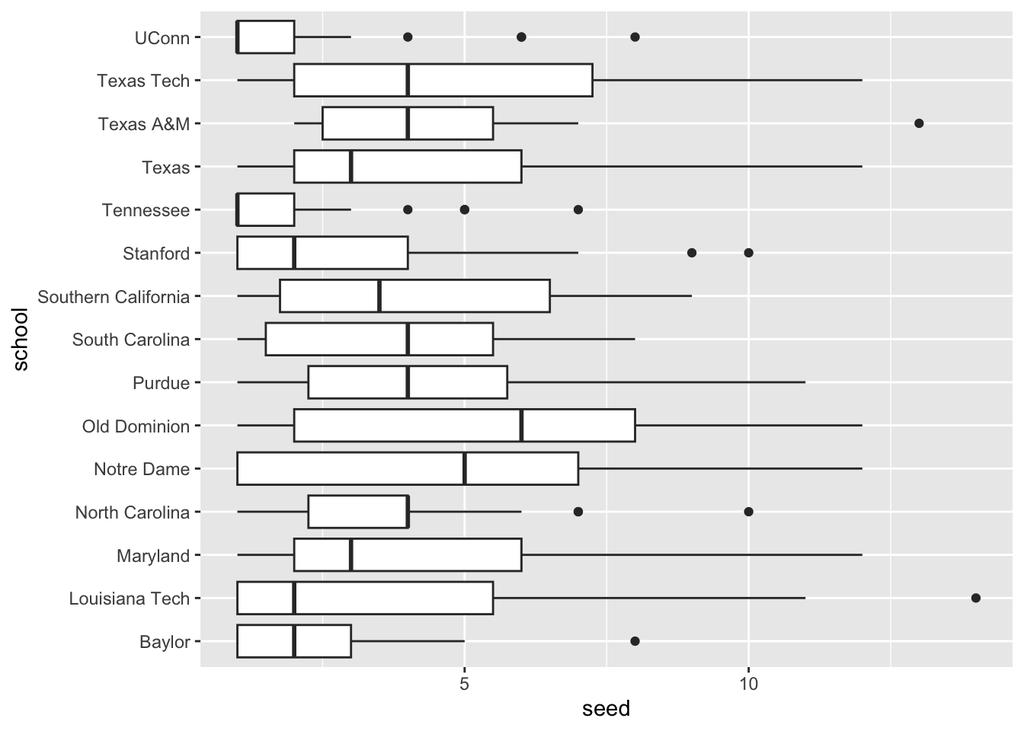

```r
ggplot(data= winners,
       mapping= aes(x= school, y= seed))+
  geom_boxplot()+
  coord_flip()
```

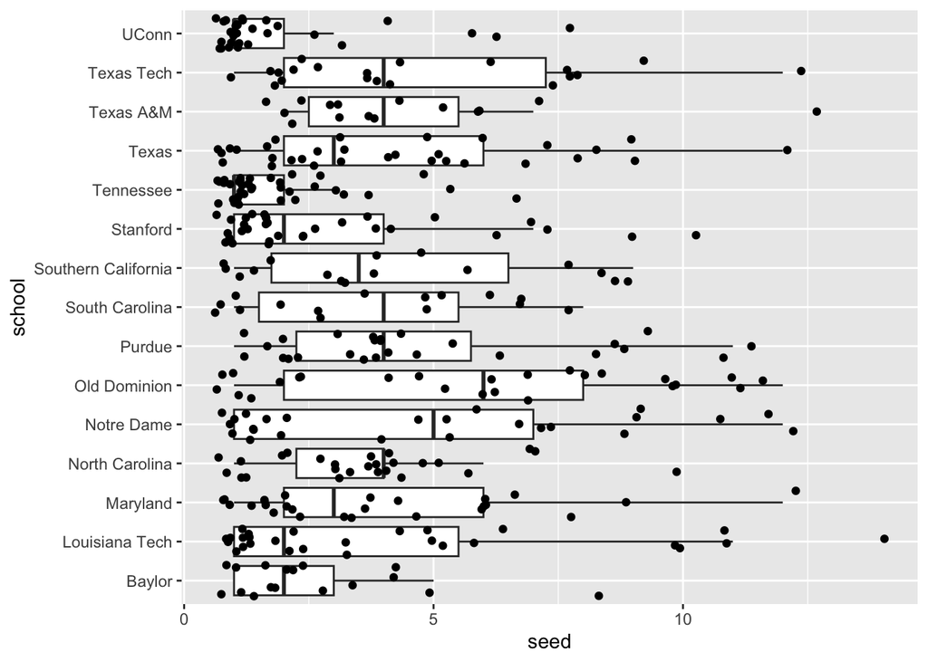

```r
ggplot(data= winners,
       mapping= aes(x= school, y= seed))+
  geom_boxplot(outlier.shape = NA)+
  geom_jitter()+
  coord_flip()
```

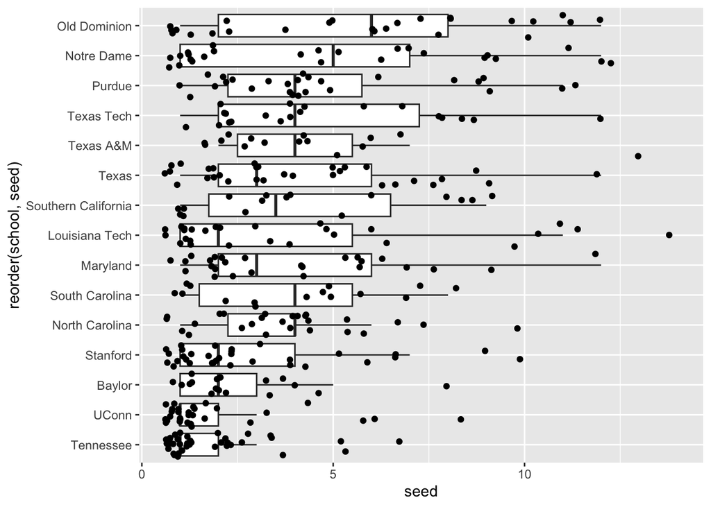

```r
ggplot(data= winners,
       mapping= aes(x= reorder(school, seed), y= seed))+
  geom_boxplot(outlier.shape = NA)+
  geom_jitter()+
  coord_flip()
```

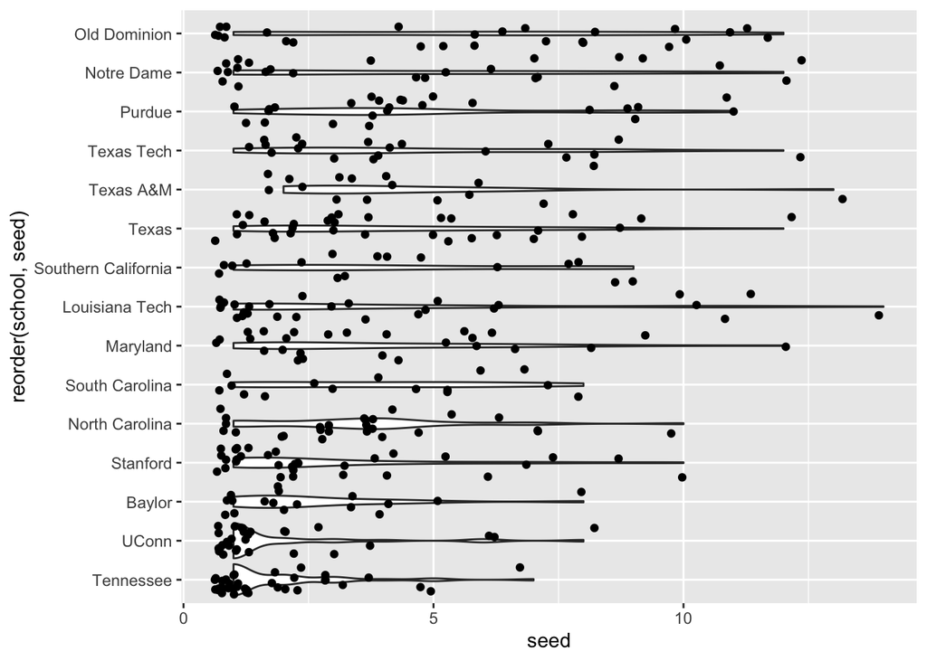

```r
ggplot(data= winners,
       mapping= aes(x= reorder(school, seed), y= seed))+
  geom_violin(outlier.shape = NA)+
  geom_jitter()+
  coord_flip()
```

In this case, the first plot (boxplot) is more informative, because we can see the distribution very clearly, including where is the 25%, what is the 50%, and where is the 75% of each school.

## Question 3

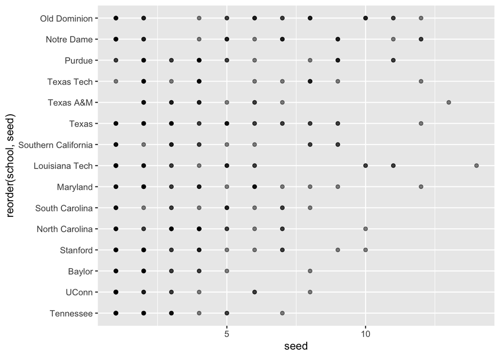

```r
ggplot(data= winners,
       mapping= aes(x= reorder(school, seed), y= seed))+
  geom_point(alpha = 0.5) +
  coord_flip()
```

This plot does not work well because geom point is not aggregated data but is a scatter plot of separate points, and it can be hard to analyze the overall distributions in this plot.

## Question 4

```r
winners_mean_sd <- winners |>
  group_by(school) |>
  summarize(across(where(is.numeric),
                   list(mean = mean,
                        sd = sd)))
```

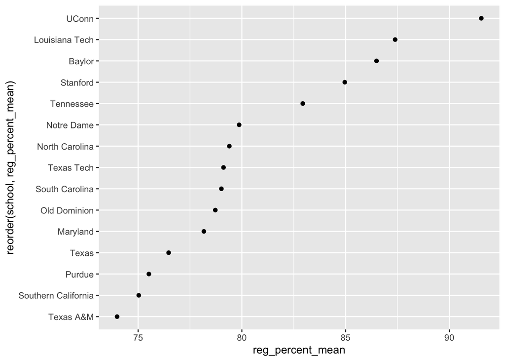

```r
ggplot(data=winners_mean_sd,
       mapping = aes(x= reorder(school, reg_percent_mean), y=reg_percent_mean )) +
  geom_point() +
  coord_flip()
```

All the teams have relatively high average winning percentage of over 74%. Texas A & M has the lowest regular season winning percentage of around 74%.

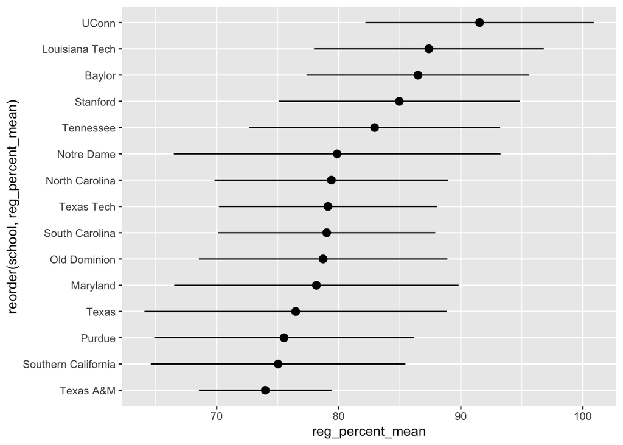

```r
ggplot(data= winners_mean_sd,
       mapping= aes(x = reorder(school, reg_percent_mean), y = reg_percent_mean)) +
  geom_pointrange(aes(ymin = reg_percent_mean - reg_percent_sd, ymax = reg_percent_mean + reg_percent_sd)) +
  coord_flip()
```

The school with the narrowest interval is Texas A&M, it means that this school has a smaller spread in average win percentages, and it’s performance is relatively consistent.

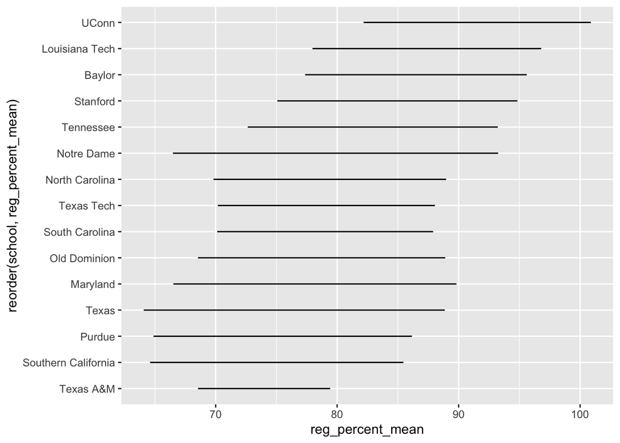

```r
ggplot(data= winners_mean_sd,
       mapping= aes(x = reorder(school, reg_percent_mean), y = reg_percent_mean)) +
  geom_linerange(aes(ymin = reg_percent_mean - reg_percent_sd, ymax = reg_percent_mean + reg_percent_sd)) +
  coord_flip()
```

I think geom_pointrange is better, as it shows both the mean (the point at the center) and the distribution of a dataset, instead of only the distribution in geom_lineage. It allows us to know both the central tendency and the spread of data.